# Gradient Descent

No Mercy for High Loss - Only Descent

Gradient descent is one of the most popular algorithms to perform optimization and by far the most common way to optimize neural networks.

Gradient descent is a way to minimize an objective function $J(\theta)$, parameterized by a model’s parameters $(\theta \in \mathbb{R}^d )$, by updating the parameters in the opposite direction of the gradient of the objective function, $\nabla J(\theta)$, with respect to the parameters $\theta$.

The learning rate, $\eta$, determines the size of the steps we take to reach a (local) minimum.

### #1 Steps Involved in Gradient Descent

#### 1. Initialize the Parameters

- Begin by initializing the model parameters $\theta$ with some values (usually small random numbers).
- These parameters will be updated iteratively to minimize the objective function.

#### 2. Calculate the Gradient

- Compute the gradient of the objective function $J(\theta)$ with respect to the parameters $\theta$. This is the derivative $\nabla J(\theta)$, which indicates the direction of the steepest ascent.

#### 3. Update the Parameters

- Update the parameters $\theta$ in the direction opposite to the gradient to minimize the objective function:
  $$\theta = \theta - \eta \nabla J(\theta)$$
  where $\eta$ is the learning rate, controlling the step size.

#### 4. Repeat Until Convergence

- Continue iterating through steps 2 and 3 until the algorithm converges, i.e., the changes in the parameters become very small or the objective function reaches a desired minimum. e.g.,
  $$\theta_{old} - \theta_{new} \approx 0.002$$

#### 5. (Optional) Check for Convergence Criteria

- Convergence can be determined by one or more of the following:
  - The gradient $\nabla J(\theta)$ becomes sufficiently close to zero.
  - The change in the value of $J(\theta)$ between iterations falls below a predefined threshold.
  - A fixed number of iterations is reached.

#### 6. Return the Final Parameters

- Once the parameters have converged, return the final optimized values of $\theta$.

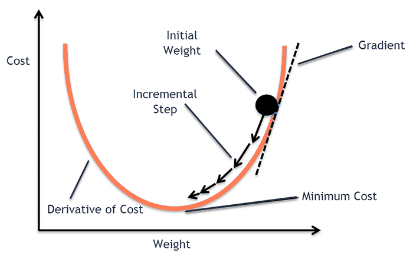

Gradient Descent Algorithm

Let say, if objective function $J(\theta)$ where $\theta \in (m, c)$, then Gradient descent will be

```
repeat until converge {
 m[i] = m[i-1] - (learning rate * slope_m)
 c[i] = c[i-1] - (learning rate * slope_c)
 }
```

where, `slope_m` = $\large \frac{\partial J}{\partial m}$ and `slope_c`= $\large \frac{\partial J}{\partial c}$

1. If Slope is positive:  
   `m[i] = m[i-1] - [(learning rate) * (+ slope_m)]`
2. If Slope is negative:  
   `m[i] = m[i-1] - [(learning rate) * (- slope_m)]`  
   `m[i] = m[i-1] + [(learning rate) * (slope_m)]`

Model is said to be converged when `m[i] - m[i-1] ≈ 0.01`

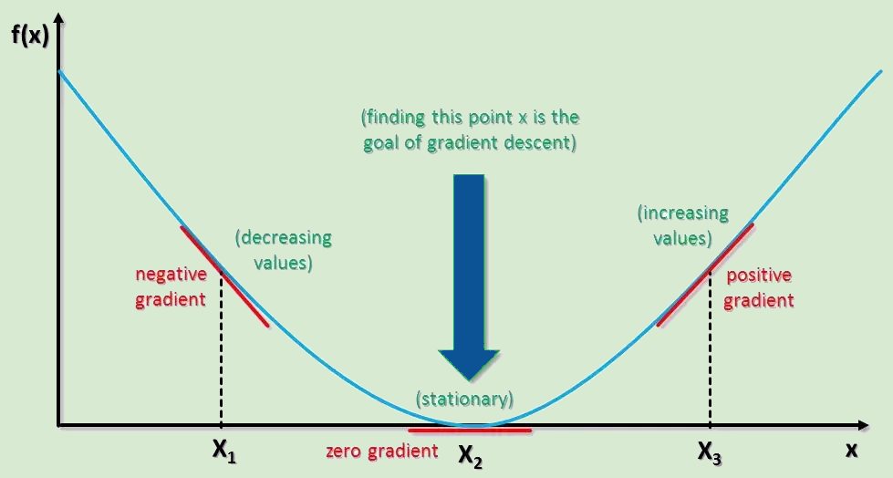

Finding Minimum from any point

### #2 Learning Rate

The learning rate is a hyperparameter in machine learning that controls the step size at which the parameters $\theta$ of a objective function $J(\theta)$ are updated during training.  
It’s important to achieve a desirable learning rate because both low and high learning rates can waste time and resources.  
- **Too large**: The algorithm might overshoot the minimum, causing divergence.  
- **Too small**: The convergence will be slow, and it might get stuck in local minima.

A **desirable learning rate** is one that’s low enough so that the model/network converges to something useful but high enough so that it can be trained in a reasonable amount of time.

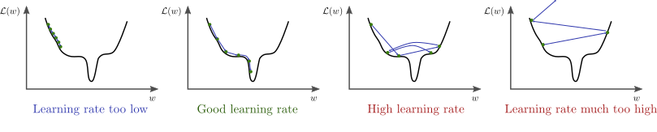

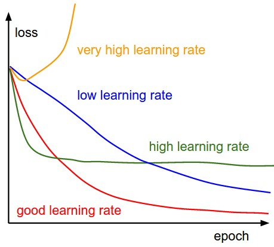

Learning Rate effect